# ACSE-7 (Optimisation & Inversion)

## Coursework part B

Part B of the coursework covers lectures 2-7. The completion time should be roughly that of part A and part C combined.

Some $\LaTeX$ definitions hidden in this cell (double-click to reveal) $ \newcommand\vec[1]{\boldsymbol{\mathrm{#1}}} \newcommand\mat[1]{\underline{\mathbf{#1}}} \newcommand\R{\mathbb{R}} \newcommand\vlam{\boldsymbol{\lambda}} $

```python
# needs to be in separate cell!
%matplotlib inline
```

```python
import numpy as np
import matplotlib.pyplot as plt
# the following allows us to plot triangles indicating convergence order
from mpltools import annotation
# scipy's optimization
import scipy.optimize as sop
import scipy.linalg as sl
import scipy.sparse as sp
import scipy.sparse.linalg as spl

# font sizes for plots
plt.rcParams['font.size'] = 16
plt.rcParams['font.family'] = 'sans-serif'
plt.rcParams['font.sans-serif'] = ['Arial', 'Dejavu Sans']
```

## From Poisson to Diffusion Equation </a>

In the lectures, we have used a finite difference discretisation of Poisson's equation in two dimensions:

$$ -\frac{\partial^2 u(x,y)}{\partial x^2} - \frac{\partial^2 u(x,y)}{\partial y^2} = f(x,y) $$

with a Finite Difference discretisation given by:

$$ \frac{-u_{i-1} + 2u_{i} -u_{i+1}}{\Delta x^2} + \frac{-u_{i-N_x} + 2u_{i} - u_{i+N_x}}{\Delta y^2} = f_i $$

where we assume a computational grid of $N_y$ rows and $N_x$ columns, giving $n=N_x\cdot N_y$ grid points. The grid values $u_i$ are numbered row by row. The values $u_{i-1}$ and $u_{i+1}$ refer to the values to the left and right of $u_i$ respectively, whereas $u_{i-N_x}$ and $u_{i+N_x}$ refer to value in the row above and below. We will assume $\Delta y=\Delta x$. In matrix form we may write

$$ \mat K \vec u = \vec f $$

with for each row $i$ associated with a grid point in the interior (away from the boundary):

$$ K_{i,i} = \frac{4}{\Delta x^2}, \text{ and } K_{i,i-N_x} = K_{i,i-1} = K_{i,i+1} = K_{i,i+N_x} = -\frac 1{\Delta x^2} $$

For the boundary rows, we imposed Dirichlet boundary conditions, and we stated, without proof, that the resulting matrix is Symmetric Positive Definite.

# Question B1

- What is your recommendation for a Krylov Subspace method to solve this linear system. Describe in one or two sentences why this method requires the matrix to be SPD.

# Answer B1

My recommendation would be that it is a finite difference discretisation problem. The matrix has to be SPD so that a quadratic function minimisation can be implemented (i.e. there is a unique direction to get the mimimum).

# Question B2

Note that for the rows associated with interior points, we have

$$ \sum_{j=1}^n K_{ij} = 0 $$

i.e. the sum of the entries in each interior row is zero. If we apply Neumann (instead of Dirichlet) boundary conditions, the same is true for all rows: both boundary and interior rows sum to zero.

- Is the matrix with Neumann boundary condition still Symmetric Positive Definite? **Hint:** consider a vector $\vec v$ whose values are all the same: $v_i=C$ for all $i$ with some constant $C$, and compute $\vec v^T\mat K\vec v$. Assuming the matrix is symmetric, and that for all other vectors $\vec v$ we still have $\vec v^T\mat K\vec v\gt 0$, what other term *does* apply to this matrix?

# Answer B2

Assume $v=(1, 1, ..., 1, 1)^{T}$

$$\vec v^T\mat K\vec v = tr(K) =\sum_{i=1}^m \sum_{j=1}^n K_{ij} = \sum_{j=1}^n 0 = 0$$

Hence, it is still possible for $\vec v^T\mat K\vec v$ to be 0 (i.e. $\vec v^T\mat K\vec v \ge 0$).

$\mat K$ is still symmetric.

Overall, $\mat K$ is Poitive semi-Definite.

# Question B3

By adding a time derivative, we can turn this PDE into the diffusion equation

$$ \frac{\partial u(x,y,t)}{\partial t} - m \frac{\partial^2 u(x,y,t)}{\partial x^2} - m\frac{\partial^2 u(x,y,t)}{\partial y^2} = 0 $$

with diffusion coefficient $m$.

With an implicit time integration (backward Euler) the discrete equation looks like:

$$ \frac{u_i^{k+1} - u_i^k}{\Delta t} + m\frac{-u_{i-1}^{k+1} + 2u_{i}^{k+1} -u_{i+1}^{k+1}}{\Delta x^2} + m\frac{-u_{i-N_x}^{k+1} + 2u_{i}^{k+1} - u_{i+N_x}^{k+1}}{\Delta y^2} = 0 $$

where the superscript ${}^{k+1}$ refers to the solution at the end of the timestep, and ${}^k$ to the value at the beginning of the timestep.

After multiplying all terms with $\Delta t$, we can write this discretisation as a linear system

$$ \mat A \vec u^{k+1} = \vec u^k $$

where the matrix $\mat A$ is given by

$$ \mat A = \mat I + m~\Delta t~\mat K $$

with identity matrix $\mat I$, and $\mat K$ the same matrix as we used for Poisson's equation above with Neumann conditions.

- Using what you already know about $\mat K$, proof that $\mat A$ is Symmetric Positive Definite.

# Answer B3

$$\mat A_{ij}=\delta_{ij}+m\Delta t*\mat K_{ij}$$

where $\delta_{ij}$ is Kronecker's Delta (i.e. if i=j, $\delta_{ij}$=1; else, $\delta_{ij}$=0)

Given K is Positive semi-Definite,

1. $\mat K$ is symmetric;
2. $\vec v^{T} \mat K \vec v \ge 0$.

For A,

1. 1 is added to diagnoal elements only, and all terms are multiplied by two positive numbers, so $\mat A$ is still symmetric;
2. Assume $\vec v=(C, C, C, ..., C, C)^T$,

$$\vec v^{T} \mat A \vec v = C^2 tr(\mat A) = C^2 [rk(\mat A)+m\Delta t *tr(\mat K)]$$$$rk(\mat A) \gt 0 \n and \n m\Delta t * tr(\mat K) \ge 0 -> \vec v^{T} \mat A \vec v >0$$

# Question B4

- We consider the use of dense vs. sparse matrices in solving this system. We use the Conjugate Gradient method to solve the linear system above on a series of computational grids where we increase the resolution and thus the number of grid points $n=N_x\cdot N_y$. We record the average time the CG method takes to perform a single iteration with the results displayed in the graph below. Describe the difference in terms of scaling for the case with dense matrices and the case with sparse matrices, and explain the reason why these differences can be observed. You only need to describe the asymptotic behaviour.

[figure not shown]

# Answer B4

Given matrices with the same size ($n$), time taken for one iteration for a sparce matrix is less than a dense. As the size is increased, the rate of increase in time differs: a sparse one's time increases linearly with size, but dense quadratically.

For a single iteration of conjugate gradient method applied on a dense matrix, multiplication of a matrix and a vector is required, where we have to multiply and add every element in the matrix $\mat G$ and the result $\vec b$ and two loops with size $n$ are needed. As a result, scaling is proportional to $n^2$ ($O(n^2)$ operation), i.e. the realtionship between time taken for a single iteration and n is 2-nd ordered.

For a single iteration of conjugate gradient method applied on a sparse matrix, it is an $O(n)$ operation i.e. scaling is proportional to $n$ only, because the sparse matrix only contains elements which are not 0, the number of which is n. To do the same multiplication, we only need a loop with size $n$.

# Question B5

- As a stopping criterion we use a relative tolerance $\epsilon_{\text{rel}}=10^{-5}$. In the next two figures, we show the overall time for the Conjugate Gradient algorithm to converge with that criterion, and the number of iterations it takes. Only the results with a sparse matrix are shown. Again describe and explain the asymptotic behaviour of both graphs. You do not need to explain the specific value of the~ slope of 0.5 in the right-hand figure. Given that we can observe a slope of 0.5 however, what is your expectation of the scaling between the condition number of the matrix and $n$?

[figure not shown]

# Answer B5

For CG method, the number of iterations required follows the following equation: $$ i \le \frac{1}{2} \sqrt{\kappa(\mat {A})} \ln (\frac{1}{\epsilon}), $$ where $\kappa$ is the condition number, and i is the number of iterations required.

The equation above shows the scale between $i$ and $\kappa$ is 0.5.

From the right figure, $i$ has a scale of 0.5 with $n$; hence, we can infer that $\kappa$ has a linear relationship with $n$.

From the figure in B4, time taken for a SINGLE iteration is linear with $n$. However, from the left figure, time taken for the ENTIRE iteration(s) has a 1.5 scale with $n$ rather than 1(see the left figure), which is caused by an increase in the number of iterations due to an increase in $\kappa$ as $n$ increases.

To summarise: $$\text{time taken for a SINGLE iteration} ∝ n ①$$

$$\text{time taken for the ENTIRE iteration(s)} ∝ n^{1.5} ②$$$$\text{time taken for the ENTIRE iteration(s)} ∝ \sqrt{\kappa}n ③$$$$\text{No. of iterations} ∝ n^{0.5} ④.$$

From relationship ② and ③, it is easy to see that the scaling between $n$ and $\kappa$ should be 1 as well.

To prove in terms of the definition, $\kappa = \lambda_{max}/\lambda_{min}$, where $\lambda$ is an eigenvalue.

$\lambda_{max}$ is proportional to $\frac{1}{\Delta x^2}$, whereas $\lambda_{min}$ does not change much. Hence, $\kappa$ is proportional to $\frac{1}{\Delta x^2}=N_x N_y=n$ and the scale between $\kappa$ and n is 1.

# Question B6

- We also measured the computational time for solving the linear system with a sparse direct method (not shown). We notice that the scaling of the computational time with the problem size $n$ was worse that linear. Explain why this is to be expected. Do you expect the scaling to be better, the same, or even worse when solving the same equation in three dimensions? Explain why.

# Answer B6

The direct method is to get the inverse of $\mat G$ and solve: $$ \mat G \vec m = \vec b \\ \vec m = \mat G^{-1} \vec b. \\ $$ To invert a matrix, an reduce echlon form has to be obtained, which is a $O(n^3)$ operation in 2D. This makes the scale between time taken and size 3.

In 3D, $n=N_x\times N_y \times N_z$. To invert such a sparse matrix, it is now a $O(n\times N_x \times N_y)=O(n^{2.333})$ operation. This makes it a better scale.

# Diffusion Equation as Image Filter (background section - no question)

The diffusion equation has many applications uch as the dispersal of microparticles through random motion (Brownian motion), the spread of a disolved substance, e.g. a pollutant in a fluid, or the spread of heat. We can also use it as a method to apply a blur effect to a photo.

First we read in a familiar looking photo:

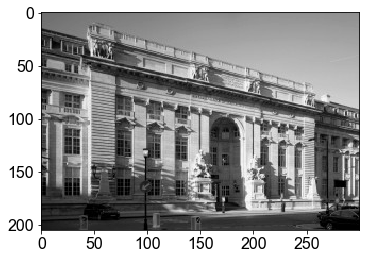

```python
img = plt.imread("RSM-BW-300x205.png")
plt.imshow(img, cmap='gray');
```

The code to assemble the matrix $\mat A$ is given by:

```python
def K_matrix(Nx, Ny, delta_x=1.0):
    """Assemble discrete Poisson matrix K

    Nx, Ny: number of gridpoint in x and y directions
    delta_x: grid distance
    """
    n = Ny * Nx
    K = sp.eye(n)*4  # main diagonal with the value 4
    K -= sp.eye(n, k=1)  # connections to grid point on the right
    K -= sp.eye(n, k=-1)  # connection to the left
    K -= sp.eye(n, k=Nx) # connection to grid point below
    K -= sp.eye(n, k=-Nx)  # connection above
    K = K / (delta_x)**2  # divide all entries by dx^2

    return K

def A_matrix(Nx, Ny, m, delta_t=1.0, delta_x=1.0):
    """Assemble discrete timestepping matrix A for diffusion equation

    Nx, Ny: number of gridpoint in x and y directions
    m: diffusion coefficient
    delta_t: time step
    delta_x: grid distance
    """
    n = Ny * Nx
    K = K_matrix(Nx, Ny, delta_x)
    A = sp.eye(n) + m * delta_t * K

    return A
```

So that a simple timestepping model takes the form:

```python
def diffusion_model(Nx, Ny, m, u0, Nt, delta_t=1.0, delta_x=1.0):
    """Solve diffusion equation and return solution in final timestep

    Nx, Ny: number of gridpoint in x and y directions
    m: diffusion coefficient
    u0: initial condition
    Nt: number of timesteps
    delta_t: time step
    delta_x: grid distance
    """

    A = A_matrix(Nx, Ny, m, delta_t=delta_t, delta_x=delta_x)
    u = u0
    for i in range(Nt):
        u = spl.spsolve(A, u)  # solve using sparse direct solver
    return u
```

In the rest of this coursework, we simply assume a fixed value for $\Delta x=1$, and also a timestep of $\Delta t=1$. The domain is assumed to be $[0,L]\times [0,H]$ with length $L=N_x\Delta x=N_x$ and height $H=N_y\Delta x=N_y$. The number of timesteps is given by $N_t$, and in the examples kept fixed at $N_t=5$, and we assume that the time $t$ runs between 0 and $T=N_t\Delta t=N_t$.

The code below shows how the diffusion model can be applied to a black and white photo. Note that we need to flatten the `img` array, which has a shape of $N_y\times N_x$, to a flat array `u` with length $n=N_x\cdot N_y$:

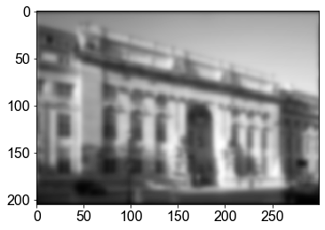

```python
Ny, Nx = img.shape
Nt = 5
m = 0.8  # what value did we use ???
u0 = img.flatten()
u1 = diffusion_model(Nx, Ny, m, u0, Nt)
img1 = u1.reshape(Ny, Nx)
plt.imshow(img1, cmap='gray')
np.save('rsm-blurred.npy', img1)
```

# Question B7

## Inversion for Diffusion Coefficient </a>

After applying the diffusion model, we have forgotten what value of the diffusion coefficient $m$ we have used. We do however still have the original photo that was used which served as the initial condition $u_{\text{ic}}$, and the blurred photo obtained from the last timestep value of $u$, which we have stored as $u_{\text{end}}$ (in the file `rsm-blurred.npy`). We therefore consider the following PDE-constrained optimisation problem:

$$ \text{minimize } f(u, m) = \int \left(u(x, y, T) -u_{\text{end}}(x, y, T)\right)^2 \mathrm{d}x\mathrm{d}y $$

subject to the PDE constraint:

$$ g(u,m) = \begin{pmatrix} \frac{\partial u(x,y,t)}{\partial t} -m\frac{\partial^2 u(x,y,t)}{\partial x^2} - m\frac{\partial^2 u(x,y,t)}{\partial y^2} \\ u(x, y, 0) - u_{\text{ic}}(x, y) \\ \frac{\partial u(x,y,t)}{\partial x} \\ \frac{\partial u(x,y,t)}{\partial y} \end{pmatrix} = \begin{pmatrix} \phantom{\frac{\partial^2}{\partial x}} 0 \phantom{\frac{\partial^2}{\partial x}} \\ \phantom{\frac{\partial u}{\partial x}} 0 \phantom{\frac{\partial u}{\partial x}} \\ \phantom{\frac{\partial u}{\partial x}} 0 \phantom{\frac{\partial u}{\partial x}} \\ \phantom{\frac{\partial u}{\partial x}} 0 \phantom{\frac{\partial u}{\partial x}} \end{pmatrix} \begin{array}{l} \text{ for } (x,y)\in [0,L]\times[0,H], t \in [0,T] \phantom{\frac{\partial^2}{\partial x}} \\ \text{ for } (x,y)\in [0,L]\times[0,H] \phantom{\frac{\partial u}{\partial x}} \\ \text{ for } x=0\text{ or x=L, and } y\in [0,H], t \in [0,T] \phantom{\frac{\partial u}{\partial x}} \\ \text{ for } y=0\text{ or y=H, and } x\in [0,L], t \in [0,T] \end{array} $$

- We decide to use the tangent-linear approach to compute the gradient of the reduced functional. Consider a perturbation $\delta m$ in the diffusion coefficient $m$, show that the resulting perturbation $\delta u(x,y,t)$ to the solution $u(x,y,t)$ satisfies the following PDE:

$$ \frac{\partial \delta u(x,y,t)}{\partial t} -m\frac{\partial^2 \delta u(x,y,t)}{\partial x^2} - m\frac{\partial^2 \delta u(x,y,t)}{\partial y^2} = \delta m\frac{\partial^2 u(x,y,t)}{\partial x^2} + \delta m\frac{\partial^2 u(x,y,t)}{\partial y^2} $$

with initial condition

$$ \delta u(x,y,0) = 0 $$

and boundary conditions

\begin{align*} \frac{\partial \delta u(x,y,t)}{\partial x} &= 0 & \text{ for } x=0\text{ or x=L, and } y\in [0,H] \\ \frac{\partial \delta u(x,y,t)}{\partial y} &= 0 & \text{ for } y=0\text{ or y=H, and } x\in [0,L] \end{align*}

# Answer B7

We have:

$$ \frac {\partial g(u,m)}{\partial u} \delta u= \begin{pmatrix} \frac{\partial \delta u(x,y,t)}{\partial t} -m\frac{\partial^2 \delta u(x,y,t)}{\partial x^2} - m\frac{\partial^2 \delta u(x,y,t)}{\partial y^2} \\ \delta u(x, y, 0) \\ \frac{\partial \delta u(x,y,t)}{\partial x} \\ \frac{\partial \delta u(x,y,t)}{\partial y} \end{pmatrix} $$

and also:

$$ \frac {\partial g(u,m)}{\partial m} \delta m= \begin{pmatrix} -\delta m\frac{\partial^2 u(x,y,t)}{\partial x^2} - \delta m\frac{\partial^2 u(x,y,t)}{\partial y^2} \\ 0 \\ \delta m \frac{\partial u(x,y,t)}{\partial x} \\ \delta m \frac{\partial u(x,y,t)}{\partial y} \end{pmatrix} $$

Given initial & boundary conditions:

$$ IC: \delta u(x,y,0) = 0 \\ BC: \frac{\partial \delta u(x,y,t)}{\partial x} = 0, \text{ for } x=0\text{ or x=L, and } y\in [0,H] \\ \frac{\partial \delta u(x,y,t)}{\partial y} = 0, \text{ for } y=0\text{ or y=H, and } x\in [0,L] \\ $$

By substituting $ \frac{\partial g}{\partial u}\delta u = -\frac{\partial g}{\partial m}\delta m $ (in L7), the resulting perturbation to the solution is: $$ \frac{\partial \delta u(x,y,t)}{\partial t} -m\frac{\partial^2 \delta u(x,y,t)}{\partial x^2} - m\frac{\partial^2 \delta u(x,y,t)}{\partial y^2} = \delta m\frac{\partial^2 u(x,y,t)}{\partial x^2} + \delta m\frac{\partial^2 u(x,y,t)}{\partial y^2} $$

# Question B8

Note that the PDE for $\delta u$ is very similar to the PDE for $u$, except for the additional right-hand side term. We can therefore implement it using

$$ \mat A \vec{\delta u}^{k+1} = \vec{\delta u}^k - \Delta t~\delta m~\mat K\vec u^{k+1} $$

where $\vec{\delta u}^{k+1}$ and $\vec{\delta u}^k$ are the numerical solutions for $\delta u$ at the end and beginning of the timestep, and $\vec{u}^{k+1}$ is the numerical solution for $u$ at the end of timestep $k$, calculated as before. The code is given by:

```python
def tangent_linear_model(Nx, Ny, kappa, u0, Nt, delta_t=1.0, delta_x=1.0, delta_m=1.0):
    """Solve tangent linear model based on perturbation in diffusion coefficient.
    Return perturbation in final timestep solution

    Nx, Ny: number of gridpoint in x and y directions
    u0: initial condition
    Nt: number of timesteps
    delta_t: time step
    delta_x: grid distance
    delta_m: perturbation in diffusion coefficient m. Set to 1 to compute gradient (see explanation below)
    """

    K = K_matrix(Nx, Ny, delta_x=delta_x)
    A = A_matrix(Nx, Ny, kappa, delta_t=delta_t, delta_x=delta_x)
    u = u0
    du = np.zeros_like(u)  # initial condition for perturbation du
    for i in range(Nt):
        u = spl.spsolve(A, u)  # solve u as before
        du = spl.spsolve(A, du-delta_t*delta_m*(K @ u))  # solve perturbation du
    return du
```

Using the `diffusion_model` code we can compute the solution $\vec u(m)$ for any value of the diffusion coefficient $m$, and using the `tangent_linear_model` function we can compute the derivative $\mathrm{d}\vec u(m)/\mathrm{d}m$ by setting $\delta m=1$:

$$ \delta u = \frac{\mathrm{d}\vec u(m)}{\mathrm{d}m} \delta m $$

```python
img = plt.imread("RSM-BW-300x205.png")
Ny, Nx = img.shape
Nt = 5
u0 = img.flatten()
# print(len(u0))
# print(Nx*Ny)
def u(m):
    """Solve diffusion equation using diffusion coefficient m.
    Keep all other inputs fixed (Nx, Ny, delta_x=1, Nt=5, etc)"""
    u1 = diffusion_model(Nx, Ny, m, u0, Nt)
    return u1

def dudm(m):
    """Compute gradient of solution u wrt diffusion coefficient m. Keep all other inputs fixed
    Keep all other inputs fixed (Nx, Ny, delta_x=1, Nt=5, etc)"""
    du = tangent_linear_model(Nx, Ny, m, u0, Nt)
    return du
```

Note that we keep all other inputs, like the initial condition, and the number of timesteps fixed.

- Write a test that verifies that the gradient `dudm` computed using the tangent linear model is correct. You may reuse code from the lecture notes, but be aware that $m$ is just a single scalar and not an array, so you may have to adjust the code.

# Answer B8

```python
def taylor_test(f, grad_f, x, h0, max_iter=20, plot_convergence=True, print_convergence=True):
    """Taylor test to verify that the function grad_f is the derivative of the function `f`

    We test:

       f(x + h) = f(x) + grad_f(x).h + O(h^2)

    f, grad_f  - function and its derivative to test
    x          - point in which to test
    h0         - initial perturbation
    max_iter   - number of times that h is halved
    plot_convergence - whether to plot the convergence of the Taylor residual f(x+h)-f(x)-grad_f(x).h
    print_convergence - prints the order of convergence between subsequent iterations."""

    residuals = []
    hnorms = []
    print('iteration / h / residue')
    for i in range(max_iter):
        r = f(x + h0) - f(x) - grad_f(x) * h0
        residuals.append(sl.norm(r))
        hnorms.append(sl.norm(h0))
        print(i+1,h0,sl.norm(r))
        h0 /= 2.


    if plot_convergence:
        fig, ax = plt.subplots(1,2, figsize=(15,4))
        ax[0].semilogy(residuals)
        ax[0].set_xlabel('iteration')
        ax[0].set_ylabel('Taylor residual $|r|$')
        ax[0].set_xticks(range(0,max_iter,2))
        ax[1].loglog(hnorms, residuals, 'b*-')
        ax[1].set_xlabel('perturbation size $\|h\|$')
        ax[1].set_ylabel('Taylor residual $|r|$')

        # NOTE: slope_marker does not seem to work in semilogy plots
        annotation.slope_marker((1e-3, 2e-1), (2, 1), invert=True, ax=ax[1], size_frac=.2)

    if print_convergence:
        residuals = np.array(residuals)
        print('Order of convergence, log(f(h_i)/f(h_{i+1}))/log(2):')
        print(np.log(residuals[:-1]/residuals[1:])/np.log(2))
```

```python
# we test the derivative around a regular polygon
h0 = np.random.random((1))[0]
print(h0)
```

```
0.8441273573161628
```

```
iteration / h / residue
1 0.8441273573161628 3.2323529160457807
2 0.4220636786580814 0.9961509083598636
3 0.2110318393290407 0.28289014067995505
4 0.10551591966452036 0.07598791386618957
5 0.05275795983226018 0.019740479285230133
6 0.02637897991613009 0.005034278572698652
7 0.013189489958065044 0.0012713863553969335
8 0.006594744979032522 0.00031947617714204324
9 0.003297372489516261 8.007449864861955e-05
10 0.0016486862447581305 2.00444174004735e-05
11 0.0008243431223790653 5.014335402585856e-06
12 0.00041217156118953264 1.2539881742991118e-06
13 0.00020608578059476632 3.135476189152796e-07
14 0.00010304289029738316 7.839320677086754e-08
15 5.152144514869158e-05 1.959910144169639e-08
16 2.576072257434579e-05 4.899862251837246e-09
17 1.2880361287172895e-05 1.2250088323814218e-09
18 6.4401806435864475e-06 3.062284731452807e-10
19 3.2200903217932237e-06 7.658578287563926e-11
20 1.6100451608966119e-06 1.9127602509729833e-11
Order of convergence, log(f(h_i)/f(h_{i+1}))/log(2):
[1.6981485  1.81612242 1.89640002 1.94461295 1.97130006 1.98538254
 1.99262225 1.99629359 1.99814237 1.99907008 1.99953476 1.99976727
 1.99988402 1.99994113 1.99997442 1.99994904 2.00011182 1.99945993
 2.00142055]
```

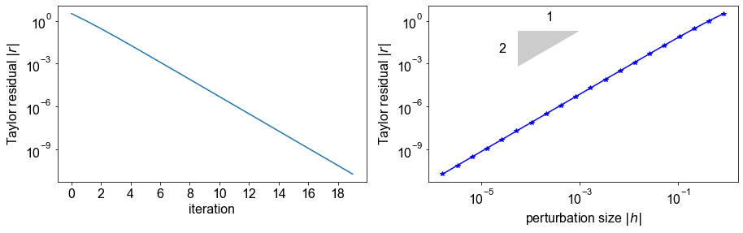

```python
taylor_test(u, dudm, m, h0)
```

# Question B9

The discrete version of the functional is given by:

$$ f(\vec u) = \left(\vec u - \vec u_{\text{end}}\right)^T \left(\vec u - \vec u_{\text{end}}\right) $$

and implemented below:

```python
img1 = np.load('rsm-blurred.npy')
u_end = img1.flatten()

def f(u):
    """Functional, return l2norm error (misfit) between final timestep solution u and u_end"""
    return (u-u_end) @ (u-u_end)
```

we also define a little helper function that computes $f(\vec u(m))$:

```python
def fhat(m):
    """Reduced functional, for given m evaluate the diffusion model to get u(m), and subtitute in functional."""
    return f(u(m))
```

- Write a python function `dfdm` that computes: $$ \frac{\mathrm{d}f(\vec u(m))}{\mathrm{d}m} = \left.\frac{\partial f(\vec u)}{\partial\vec u}\right|_{\vec u=\vec u(m)}\cdot\frac{\mathrm{d}\vec u}{\mathrm{d}m} $$ Write a test that verifies the gradient is correct.

# Answer B9

```python
def dfdm(m, delta_x=1.0):
    return 2*(u(m) - u_end) @ dudm(m)
```

```
iteration / h / residue
1 0.8441273573161628 47.6464792725956
2 0.4220636786580814 15.920545389304852
3 0.2110318393290407 4.741443083694302
4 0.10551591966452036 1.3075814425797625
5 0.05275795983226018 0.34445956896539853
6 0.02637897991613009 0.08847933417433906
7 0.013189489958065044 0.022426923293154155
8 0.006594744979032522 0.005645871617645357
9 0.003297372489516261 0.0014164087710516662
10 0.0016486862447581305 0.0003547228532681366
11 0.0008243431223790653 8.87584877649009e-05
12 0.00041217156118953264 2.2199355775012978e-05
13 0.00020608578059476632 5.551056425757784e-06
14 0.00010304289029738316 1.3879163389412364e-06
15 5.152144514869158e-05 3.469981166772111e-07
16 2.576072257434579e-05 8.675190837281734e-08
17 1.2880361287172895e-05 2.16882744746483e-08
18 6.4401806435864475e-06 5.422105808702525e-09
19 3.2200903217932237e-06 1.3555310924009497e-09
20 1.6100451608966119e-06 3.3888335668667765e-10
Order of convergence, log(f(h_i)/f(h_{i+1}))/log(2):
[1.58147985 1.74749164 1.85842541 1.92449425 1.96092222 1.98010882
 1.98996348 1.99495864 1.9974735  1.99873529 1.99936728 1.99968355
 1.99984175 1.99992087 1.99996043 1.99998022 1.9999901  1.99999506
 1.99999752]
```

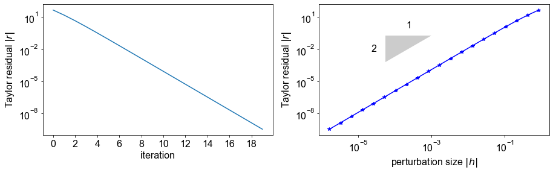

```python
taylor_test(fhat, dfdm, m, h0)
```

# Question B10

We decide to use the following minimisation algorithm:

```python
def optimize(dfdm, m0):
    """Algorithm to find stationary point for f(m) by solving df(m)/dm=0

    dfdm: a function that returns the gradient of f
    m0: initial guess"""

    m_i = m0
    for i in range(100):  # fixed number of maximum iterations
        gradf_i = dfdm(m_i)
        # stopping criterion
        if abs(gradf_i) < 1e-5:
            break

        if i>0:
            # approximate the second derivative:
            hess = (gradf_i - gradf_prev) / (m_i - m_prev)
        else:
            # first step: no good approximation, but value should be
            # large enough to ensure the initial step is small
            hess = 100.

        # store previous values:
        gradf_prev = gradf_i
        m_prev = m_i

        # update step:
        m_i = m_prev - gradf_i/hess
        print('Iteration {}, value: {}'.format(i, m_i))
    else:
        print('Maximum number of iterations reached!')

    return m_i
```

- What is the specific name of the algorithm above, a variant of the Newton method? Why can we not use the standard Newton method? Use the above code to find the value of $m$ that was used to blur the photo. You will find that your initial guess needs to be roughly between 1 and 5. The algorithm does not converge for many values outside that range. Is this to be expected, and how could we improve it? (You do not need to actually implement this improvement)

# Answer B10

The method above is secant method: $$ \vec x_{i+1}=\vec x_i - \frac{F(\vec x_i)}{F'(\vec x_i)}\\ F'(\vec x_i) \approx \frac{F(\vec x_{i+1})-F(\vec x_i)}{\vec x_{i+1}-\vec x_i}\\ $$ , where $F$ is Jacobian (gradient) and $F'$ is Hessian (2nd order derivative).

From the algorithm, we can get m $\approx 0.8$.

The standard Newton method follows local convergence theory i.e. $\vec x_0$ must be near $\vec x^*$ \text(stationary point), requiring:

1. F is differentiable and F' is Lipschitz continuous;
2. $F(\vec x^*)=0$;
3. $F' (\vec x^*)$ is not singular.

, otherwise it breaks down or does not always converge if Hessian is not SPD.

This is expected, since it is usually not possible to find the limit of right answer to ensure the norm of difference between i+1-th iteration and the stationary point is less than i-th ($||\vec x_{i+1} - \vec x^*|| < ||\vec x_{i} -\vec x^*|| $). Also, for assumption 3, $F' (\vec x^*)$ may not be singular. These two situations could both reault in a divergent answer.

To improve, a line search technique can be asserted into secant method.

```python
m0=1.2
optimize(dfdm, m0)
```

```
Iteration 0, value: 0.5866286811948931
Iteration 1, value: 0.9379380828065718
Iteration 2, value: 0.845494292952724
Iteration 3, value: 0.7894708778349431
Iteration 4, value: 0.8007718336039427
Iteration 5, value: 0.8000129450814324
Iteration 6, value: 0.7999999840404198
```

```
0.7999999840404198
```

# Question B11

## Variable Diffusion Coefficient

To apply a blur effect that varies throughout the photo, we consider a spatially varying diffusion coefficient $m(x,t)$

$$ \frac{\partial u(x,y,t)}{\partial t} - m(x,t) \frac{\partial^2 u(x,y,t)}{\partial x^2} - m\frac{\partial^2 u(x,y,t)}{\partial y^2} = 0 $$

or in discretised form:

$$ \frac{u_i^{k+1} - u_i^k}{\Delta t} + m_i\frac{-u_{i-1}^{k+1} + 2u_{i}^{k+1} -u_{i+1}^{k+1}}{\Delta x^2} + m_i\frac{-u_{i-N_x}^{k+1} + 2u_{i}^{k+1} - u_{i+N_x}^{k+1}}{\Delta y^2} = 0 $$

where $m_i$ are the entries of a vector $\vec m$ storing the different values of the diffusion coefficient at the grid points.

Again, we can write this as a linear system

$$ \mat A \vec u^{k+1} = \vec u^k $$

where now

$$ \mat A = \mat I + \Delta t~\mat{diag}(\vec m)~\mat K $$

with $\mat{diag}(\vec m)$ the diagonal matrix whose only nonzero entries are along the main diagonal, and are given by the entries of $\vec m$.

The implementation is given below:

```python
def A_matrix(Nx, Ny, m, delta_t=1.0, delta_x=1.0):
    """Assemble discrete timestepping matrix A for diffusion equation
    with variable diffusion

    Nx, Ny: number of gridpoint in x and y directions
    m: diffusion coefficient in all gridpoints, array of length Nx*Ny
    delta_t: time step
    delta_x: grid distance
    """

    n = Ny * Nx
    K = K_matrix(Nx, Ny, delta_x)
    A = sp.eye(n) + delta_t * sp.diags(m) @  K

    return A
```

- Show that the matrix $\mat A$ is *not* symmetric (either by mathematical proof or by experiment), assuming the values of $\vec m$ are not all the same.

# Answer B11

```
205 300
Is the matrix we are testing symmetric? False
```

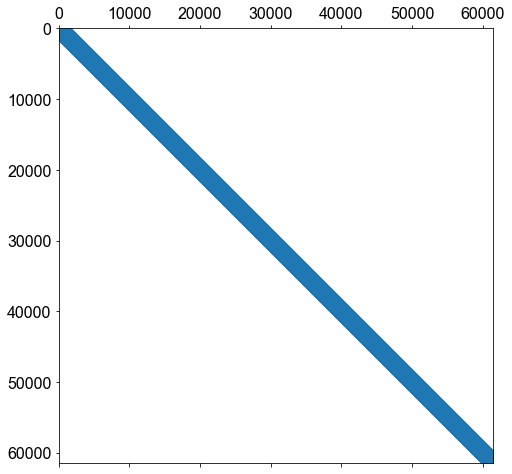

```python
print(Ny,Nx)
m_try=np.random.random(Ny*Nx)
A_11=A_matrix(Nx, Ny, m_try)
plt.figure(figsize=(8,8))
def symmetric_check(A,n):
    upper=[]
    lower=[]
    for i in range(A.shape[0]-n):
        upper.append(A[i,i+n])
        lower.append(A[i+n,i])
    upper=np.array(upper)
    lower=np.array(lower)

    return np.allclose(upper,lower)
print("Is the matrix we are testing symmetric?",symmetric_check(A_11,300))
plt.spy(A_11)
```

# Question B12

We now need to redefine the `diffusion_model` based on the new `A_matrix`. This code works exactly as before, except we now return not just the solution at the last timestep, but also all inbetween solutions in a list:

```python
def diffusion_model(Nx, Ny, m, u0, Nt, delta_t=1.0, delta_x=1.0):
    """Solve diffusion equation with variable diffusion,
    and return the solution in all timesteps

    Nx, Ny: number of gridpoint in x and y directions
    m: diffusion coefficient in all gridpoints, array of length Nx*Ny
    u0: initial condition
    Nt: number of timesteps
    delta_t: time step
    delta_x: grid distance
    """

    A = A_matrix(Nx, Ny, m, delta_t=delta_t, delta_x=delta_x)
    u = []
    ui = u0
    for i in range(Nt):
        ui = spl.spsolve(A, ui)
        u.append(ui)
    return u
```

We use the model on a different photo, and run the model to apply the blurring effect.

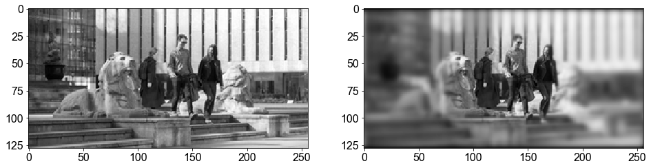

```python
# read the input image, which forms the initial condition u_ic:
img = plt.imread('queens.png')
fig, ax = plt.subplots(1,2, figsize=(16,8))
ax[0].imshow(img, cmap='gray')

# This sets up the  spatially varying diffusion coefficient in an array m
# that increases towards the boundaries
# However, after this cell we will "forget" what m was, and try to retreive it
# by solving the optimisation problem described further below
Ny, Nx = img.shape
x, y = np.meshgrid(np.arange(Nx), np.arange(Ny))
x0 = Nx/2.; y0 = Ny/2.
m_grid = np.exp(-1/100./(((x-x0)/Nx/0.75)**4+((y-y0)/Ny/1.2)**4+1e-10))
m = m_grid.flatten()

# apply the filter based on this vector m:
u0 = img.flatten()
u = diffusion_model(Nx, Ny, m, u0, 5)

# plot the resulting image, and store it in a file to be used as u_end later
img1 = u[-1].reshape(img.shape)  # image based on the final timestep solution u[-1]
np.save('queens-blurred.npy', img1)
ax[1].imshow(img1, cmap='gray');
```

After applying the filter, again we have lost the vector of diffusion coefficients $\vec m$. Like before, we would like to recover these values using a PDE-constrained optimisation problem using the same functional $f(u, m)$ as before. This time we formulate it as a *discrete optimisation problem*:

$$ \text{minimize } f(\vec u, \vec m) = \left(\vec u^{N_t}-\vec u_{\text{end}}\right)^T \left(\vec u^{N_t}-\vec u_{\text{end}}\right) $$

subject to the discrete PDE constraint

$$ g(\vec u, \vec m) = \begin{pmatrix} \mat A & 0 & 0 & 0 & \cdots & 0\\ -\mat I & \mat A & 0 & 0 &\cdots & 0\\ 0 & -\mat I & \mat A & 0 & \cdots & 0 \\ \vdots & \vdots & \ddots & \ddots & \cdots & 0 \\ 0 & 0 & \cdots & -\mat I & \mat A & 0\\ 0 & 0 & \cdots &0 & -\mat I & \mat A \end{pmatrix} \begin{pmatrix} \vec u^1 \\ \vec u^2 \\ \vec u^3 \\ \vdots \\ \vec u^{N_t-1} \\ \vec u^{N_t} \end{pmatrix} - \begin{pmatrix} \vec u_{\text{ic}} \\ 0 \\ 0 \\ \vdots \\ \phantom{^{N}} 0 \phantom{^{N}} \\ \phantom{^{N}} 0 \phantom{^{N}} \end{pmatrix} = \begin{pmatrix} 0 \\ 0 \\ 0 \\ \vdots \\ \phantom{^{N}} 0 \phantom{^{N}} \\ \phantom{^{N}} 0 \phantom{^{N}} \end{pmatrix} $$

Here the vector $\vec u$ represents the entire discrete solution at all timesteps, and therefore has a length of $N_t\cdot N_x \cdot N_y$, and is composed of (sub)-vectors $\vec u^k$ for the solution at time-step $k$. The above matrix system thus describes the same timestepping sequence as we implemented above in `diffusion_model`:

$$ \mat A\vec u^1 = \vec u_{\text{ic}} \\ -\mat I\vec u^1 + \mat A\vec u^2 = 0 \implies A\vec u^2 = \vec u^1 \\ \vdots \\ -\mat I\vec u^{N_t-1} + \mat A\vec u^{N_t} = 0 \implies A\vec u^{N_t} = \vec u^{N_t-1} $$

- We decide to solve this optimisation problem using a gradient-based optimisation algorithm, where the gradient is computed using the adjoint technique. Why can we not use the tangent linear approach as before (efficiently)? What are the three steps we need to take to compute this gradient?

# Answer B12

The tangent-linear approach would not be practically possible. We can solve the perturbation $\delta \vec u$ in $\vec u$ for any perturbation $\delta \vec m$ , but since there are infinitely many possibilities for the source perturbation, we would never be able to compute the complete gradient $df/d\vec m$ in this way.

3 Steps for the gradient-based method would be:

1. For a given $\vec m$, compute $\vec u(\vec m)$;
2. Use $\vec m$ and $\vec u$ to solve the adjoint equation for $\lambda$: $$ \left(\frac{\partial g(\vec u, \vec x)}{\partial \vec u}\right)^T \vlam = \left(\frac{\partial f(\vec u, \vec m)}{\partial \vec u}\right)^T $$

Note that since $g(\vec u, \vec x)=\mat A\vec u - \vec b$ is linear, this becomes simply

$$ \mat A^T \vlam = \left(\frac{\partial f(\vec u, \vec m)}{\partial \vec u}\right)^T $$

The right hand side is given by function dfdu.

1. Assembly the derivative:

$$ \frac{d\hat f(\vec m)}{d\vec m} = \frac{\partial f(\vec u, \vec m)}{\partial \vec m} - \vlam\cdot \frac{\partial g(\vec u, \vec m)}{\partial \vec m} $$

# Question B13

- Derive the (discrete) adjoint equation for this problem. Work out how the resulting linear system can be solved timestep by timestep. In what order are the timesteps best solved?

# Answer B13

From B12 Step 2, there is the adjoint equation: $$ \underset{\bf U\times U}{\left(\frac{\partial g(\vec u, \vec m)}{\partial \vec u}\right)^T} \underset{\bf U\times 1}{\vlam} = \underset{\bf U\times 1}{\left(\frac{\partial f(\vec u,\vec m)}{\partial \vec u}\right)^T} $$

where $U$ is the number of discretised equations (in time and space). For the continuous case, we learned that $\lambda$ satisfies a PDE that we solve backwards in time and which is related, but not the same as the PDE we solve for $\vec u$.

A natural question is to ask what is the relation between the vector $\lambda$ in the discrete case, and the function $\lambda$ in the continous case.

For simplicity's sake let us assume that the numerical model that corresponds to $g(u, m)=0$ is linear. As we have seen in the discretised 1D advection example, the structure of our model looks like

$$ g(\vec u, \vec m) = \begin{pmatrix} \mat A_{1,1} \\ \mat A_{2,1} & \mat A_{2,2} \\ & \mat A_{3,2} & \mat A_{3,3} \\ & & \mat A_{4,3} & \mat A_{4,4} \\ & & & \ddots & \ddots \end{pmatrix} \begin{pmatrix} \vec u^1 \\ \vec u^2 \\ \vec u^3 \\ \vec u^4 \\ \vdots \end{pmatrix} - \begin{pmatrix} \vec b^1 \\ \vec b^2 \\ \vec b^3 \\ \vec b^4 \\ \vdots \end{pmatrix} = 0 $$

where each of the $\mat A_{n,n}$ and $\mat A_{n,n-1}$ are $N_x\times N_x$ blocks for each time level $n$, $1\leq n \leq N_t$, and we have split up the solution vector $\vec u$ of length $N_t\cdot N_x$ into $N_t$ vectors $\vec u^n$ of length $N_x$ corresponding to the numerical solution at each time level. The $\vec b^n$ are forcing terms at each time level. For explicit finite difference models the diagonal block $\mat A^{n,n}$ is simply the identity matrix, so we can work out the solution $\vec u^n$ for time level $n$ directly, as all other references are to the previous time level $\vec u^{n-1}$ (via the $\mat A^{n, n-1}$ block). In implicit models we need to do a linear solve involving $\mat A^{n,n}$ at each time level.

From now on we will call this model the forward model, as it corresponds to the PDE we solve for $u$ forward in time. Because we assumed forward model (represented by $g(u,m)=0$) is linear, $\partial g/\partial u$ is based on the same matrix:

$$ \frac{\partial g(u, m)}{\partial u} = \begin{pmatrix} \mat A_{1,1} \\ \mat A_{2,1} & \mat A_{2,2} \\ & \mat A_{3,2} & \mat A_{3,3} \\ & & \mat A_{4,3} & \mat A_{4,4} \\ & & & \ddots & \ddots \end{pmatrix} $$

The adjoint equation gives rise to a linear system of the following form

$$ \begin{pmatrix} \mat A_{1,1}^T & \mat A_{2,1}^T \\ & \mat A_{2,2}^T & \mat A_{3,2}^T \\ & & \mat A_{3,3}^T & \mat A_{4,3}^T \\ & & & \ddots & \ddots \\ & & & & \mat A_{N_t-1, N_t-1}^T & \mat A_{N_t, N_t-1}^T \\ & & & & & \mat A_{N_t, N_t}^T \end{pmatrix} \begin{pmatrix} \vlam^1 \\ \vlam^2 \\ \vlam^3 \\ \vdots \\ \vlam^{N_t-1} \\ \vlam^{N_t} \end{pmatrix} = \begin{pmatrix} \frac{\partial f}{\partial \vec u^1} \\ \frac{\partial f}{\partial \vec u^2} \\ \frac{\partial f}{\partial \vec u^3} \\ \vdots \\ \frac{\partial f}{\partial \vec u^{N_t-1}} \\ \frac{\partial f}{\partial \vec u^{N_t}} \\ \end{pmatrix}, $$

Note that the natural way to solve this system is to actually go backwards through the time levels, i.e. first we solve the last row:

$$ \mat A_{N_t, N_t}^T \vlam^{N_t} = \frac{\partial f}{\partial \vec u^{N_t}}, $$

then using $\vlam^{N_t}$, we solve for $\vlam^{N_t-1}$

$$ \mat A_{N_t-1, N_t-1}^T \vlam^{N_t-1} + \mat A_{N_t, N_t-1}^T\vlam^{N_t} = \frac{\partial f}{\partial \vec u^{N_t-1}} $$

# Question B14

We provide you with following code, implementing the backward model (which you should be able to relate to your previous answer):

```python
def backward_model(Nx, Ny, m, Nt, u_Nt):
    """Solve adjoint equation and return the adjoint solution in all timesteps

    Nx, Ny: number of gridpoint in x and y directions
    m: diffusion coefficient in all gridpoints, array of length Nx*Ny
    u_Nt: forward solution in last timestep
    """

    A = A_matrix(Nx, Ny, m)
    lam = 2*(u_Nt - u_end)  # right-hand side in last time step

    # first collect solutions in reverse order:
    lambdas = []
    for i in range(Nt):
        lam = spl.spsolve(A.T, lam)
        lambdas.append(lam)

    # then reverse the list, so that the returned list is in the correct order
    return lambdas[::-1]
```

Again, we define

$$ \hat f(\vec m) = f(\vec u(\vec m), \vec m) $$

where $\vec u(\vec m)$ is the "forward" solution to the discretised PDE $g(\vec u,\vec m)=0$. This is implemented below:

```python
img1 = np.load('queens-blurred.npy')
Ny, Nx = img1.shape
Nt = 5
u_end = img1.flatten()

def f(u_Nt):
    """Functional based on final-timestep forward solution"""
    return (u_Nt-u_end) @ (u_Nt-u_end)

def fhat(m):
    """Reduced functional: compute forward solution for given array of grid-point diffusion coefficients
    and subtitute into functional"""
    u = diffusion_model(Nx, Ny, m, u0, Nt)
    fu = f(u[-1])
    print('f(u(m)): ', fu)
    return fu
```

- Implement the derivative $\mathrm{d}\hat f(\vec m)/\mathrm{d}\vec m$ in a python function `dfdm`. As always, test your derivative: i.e. write a test that verifies that `dfdm` is a derivative of `fhat` above.

**Hint**: You may use the following expression:

\begin{align*} \left(\vlam^T \frac{\partial g(\vec u, \vec m)}{\partial\vec m}\right)_i =\sum_{k=1}^{N_t} \Delta t\lambda^k_i \left(\mat K\vec u^k\right)_i \end{align*}

where $\lambda^k_i$ is the $i$ entry of the adjoint solution $\vlam^k$ at timestep $k$ (the $i$th entry in the $k$th array of the list of arrays returned by `backward_model`). Note that there is no summation over $i$ in the last expression: the shape of the matrix $\partial g/\partial\vec m$ is $(Nt\cdot n)\times n$, so $\vlam^T \partial g/\partial\vec m$ is a $n$-vector whose $i$-th entry is given above. Similarly $(\mat K\vec u^k)_i$ means the $i$-th entry of the vector given by the matrix-vector multiplication $\mat K\vec u^k$ where $\vec u^k$ is the solution in the $k$-th timestep (returned as a list of arrays by `diffusion_model`).

# Answer B14

```python
def dfdm(m, delta_x=1.0, delta_t=1.0):
    #prerequisite
    K = K_matrix(Nx, Ny, delta_x)
    #print("K",K.shape)
    # step 1
    u_model = np.array(diffusion_model(Nx, Ny, m, u0, 5))
    #print("u",u_model.shape)
    u_Nt=u_model[-1]
    pfpm=0

    # step 2
    lam = np.array(backward_model(Nx, Ny, m, Nt, u_Nt))
    #print("lambda",lam.shape)
    lambda_dot_dgdm = delta_t * lam[0] @ (K @ u_model[0])
    for k in range(1,Nt):
        lambda_dot_dgdm+=delta_t * lam[k] @ (K @ u_model[k])

    # step 3
    #print("=====")
    return pfpm - lambda_dot_dgdm
print(m)
```

```
[0.95702774 0.95587101 0.95467956 ... 0.95305033 0.95429851 0.9555098 ]
```

```
iteration / h / residue
f(u(m)):  163.7961149880474
f(u(m)):  0.0
1 0.8441273573161628 163.7961149880474
f(u(m)):  93.85063842805391
f(u(m)):  0.0
2 0.4220636786580814 93.85063842805391
f(u(m)):  50.94106308539121
f(u(m)):  0.0
3 0.2110318393290407 50.94106308539121
f(u(m)):  24.827243332293683
f(u(m)):  0.0
4 0.10551591966452036 24.827243332293683
f(u(m)):  10.334594996496882
f(u(m)):  0.0
5 0.05275795983226018 10.334594996496882
f(u(m)):  3.637544714295346
f(u(m)):  0.0
6 0.02637897991613009 3.637544714295346
f(u(m)):  1.1168996622802911
f(u(m)):  0.0
7 0.013189489958065044 1.1168996622802911
f(u(m)):  0.31300102674075536
f(u(m)):  0.0
8 0.006594744979032522 0.31300102674075536
f(u(m)):  0.08312561820566675
f(u(m)):  0.0
9 0.003297372489516261 0.08312561820566675
f(u(m)):  0.02143853617906486
f(u(m)):  0.0
10 0.0016486862447581305 0.02143853617906486
f(u(m)):  0.005445009575512345
f(u(m)):  0.0
11 0.0008243431223790653 0.005445009575512345
f(u(m)):  0.0013721350256286618
f(u(m)):  0.0
12 0.00041217156118953264 0.0013721350256286618
f(u(m)):  0.00034440753262448615
f(u(m)):  0.0
13 0.00020608578059476632 0.00034440753262448615
```

[output cut: 11 more lines]

```
17 1.2880361287172895e-05 1.3504050271534544e-06
f(u(m)):  3.3764358421319663e-07
f(u(m)):  0.0
18 6.4401806435864475e-06 3.3764358421319663e-07
f(u(m)):  8.441618780036775e-08
f(u(m)):  0.0
19 3.2200903217932237e-06 8.441618780036775e-08
f(u(m)):  2.1104708469803395e-08
f(u(m)):  0.0
20 1.6100451608966119e-06 2.1104708469803395e-08
Order of convergence, log(f(h_i)/f(h_{i+1}))/log(2):
[0.80346267 0.88153749 1.03690499 1.26444223 1.50644496 1.7034654
 1.83526029 1.91280232 1.95508676 1.97719991 1.98851213 1.99423386
 1.99711134 1.99855427 1.99927679 1.99963831 1.99981913 1.99990956
 1.99995478]
```

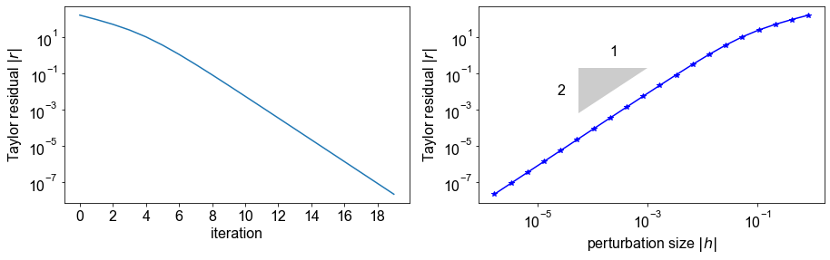

```python
taylor_test(fhat, dfdm, m, h0)
```